# Project_All_life_Credit_Card_Clustering

## Create cluster profile using K-means(k=3)

```python
cluster_profile
```

| K_means_segments | Avg_Credit_Limit | Total_Credit_Cards | Total_visits_bank | Total_visits_online | Total_calls_made | count_in_each_segment |
| --- | --- | --- | --- | --- | --- | --- |
| 0 | 33782.383420 | 5.515544 | 3.489637 | 0.981865 | 2.000000 | 386 |
| 1 | 12174.107143 | 2.410714 | 0.933036 | 3.553571 | 6.870536 | 224 |
| 2 | 141040.000000 | 8.740000 | 0.600000 | 10.900000 | 1.080000 | 50 |

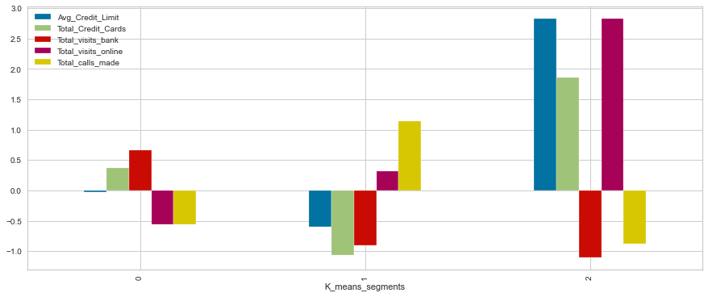

```python
subset_scaled_df.groupby('K_means_segments').mean().plot.bar(figsize=(15,6));
```

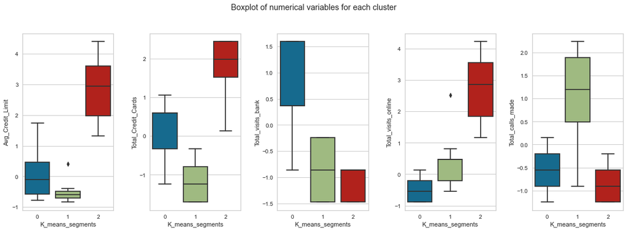

```python
fig, axes = plt.subplots(1, 5,  figsize=(16, 6))
fig.suptitle('Boxplot of numerical variables for each cluster')
counter = 0
for ii in range(5):
    sns.boxplot(ax=axes[ii],y=subset_scaled_df.iloc[:,ii],x=subset_scaled_df['K_means_segments'])
    counter = counter+1

fig.tight_layout(pad=2.0)
```

**Insights**

- Clusters 0 :
  - Avg_Credit_Limit is right at the average
  - Total_Credit_Cards is slightly higher than average
  - Total_visits_bank is slightly higher than average
  - Total_visits_onlinine is slightly lower than average
  - Total_calls_made is slightly lower than average
- Cluster 1 :
  - Avg_Credit_Limit is slightly lower than the average
  - Total_Credit_Cards is lower than average
  - Total_visits_bank is lower than average
  - Total_visits_onlinine is slightly higher than average
  - Total_calls_made is higher than average
- Cluster 2 :
  - Avg_Credit_Limit is much higher than the average
  - Total_Credit_Cards is much higher than average
  - Total_visits_bank is lower than average
  - Total_visits_onlinine is much higher than average
  - Total_calls_made is lower than average

## Hierarchical clustering Analysis

### Review different linkage methods and distance measurements. Using Cophenet index as a comparison metric

```python
distance_metrics = [ 'euclidean','chebyshev','mahalanobis','cityblock']
linkage_methods = ['single', 'complete', 'average', 'weighted']
high_cophenet_corr = 0
high_dm_lm = [0,0]
for dm in distance_metrics:
    for lm in linkage_methods:
        Z = linkage(subset_scaled_df, metric=dm, method=lm)
        c, coph_dists = cophenet(Z , pdist(subset_scaled_df))
        print('Cophent correlation for distance metrics {} and linkage method {} is {}'.format(dm,lm,c))
        if high_cophenet_corr < c:
            high_cophenet_corr = c
            high_dm_lm[0] = dm
            high_dm_lm[1] = lm
print('*'*115)
print('Highest cophenet correlation is {}, which is obtained with {} distance metric and {} linkage method'.format(high_cophenet_corr ,high_dm_lm[0],high_dm_lm[1]))
```

```
Cophent correlation for distance metrics euclidean and linkage method single is 0.8788676940541079
Cophent correlation for distance metrics euclidean and linkage method complete is 0.8860521900934342
Cophent correlation for distance metrics euclidean and linkage method average is 0.9168725782090766
Cophent correlation for distance metrics euclidean and linkage method weighted is 0.9133393931042242
Cophent correlation for distance metrics chebyshev and linkage method single is 0.8978014062578786
Cophent correlation for distance metrics chebyshev and linkage method complete is 0.8623270916886306
Cophent correlation for distance metrics chebyshev and linkage method average is 0.9160784250471772
Cophent correlation for distance metrics chebyshev and linkage method weighted is 0.9109044268579872
Cophent correlation for distance metrics mahalanobis and linkage method single is 0.8959952526724227
Cophent correlation for distance metrics mahalanobis and linkage method complete is 0.6550023123197868
Cophent correlation for distance metrics mahalanobis and linkage method average is 0.8467618899578886
Cophent correlation for distance metrics mahalanobis and linkage method weighted is 0.8207917162822879
Cophent correlation for distance metrics cityblock and linkage method single is 0.8406488764445825
Cophent correlation for distance metrics cityblock and linkage method complete is 0.8890360877047411
Cophent correlation for distance metrics cityblock and linkage method average is 0.9149250127652871
Cophent correlation for distance metrics cityblock and linkage method weighted is 0.8901622514742297
Highest cophenet correlation is 0.9168725782090766, which is obtained with euclidean distance metric and average linkage method
```

**Insights:**

- Average Linkage method with euclidean distance has the highest Cophenet correlation 0.917

### Plot dendrograms for the different linkage methods

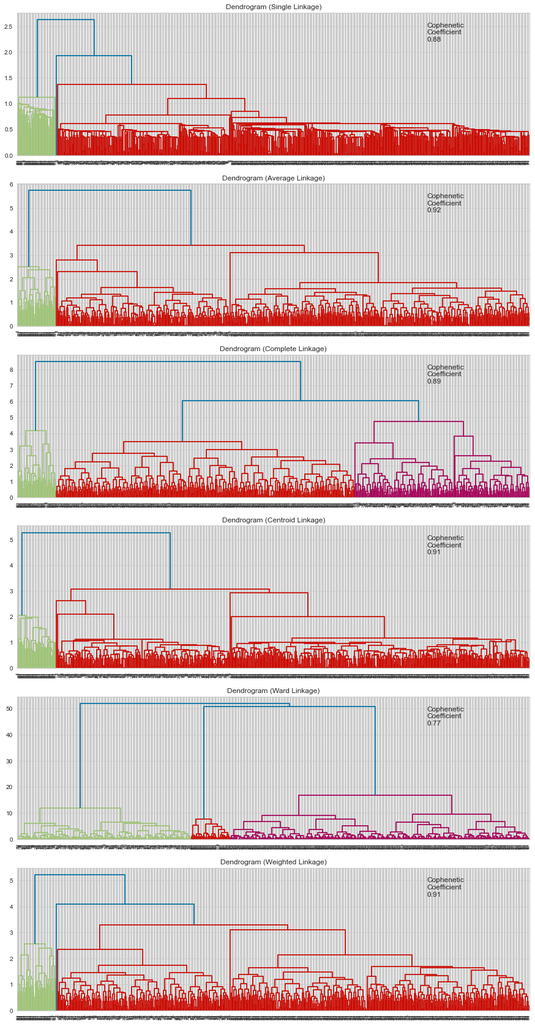

```python
# List of all linkage methods to check
methods = ['single',
           'average',
           'complete',
           'centroid',
           'ward',
          'weighted']

# Calculate the pairwise distance form the dataset to be used in the cophenetic correlation calculation
#pw_distance = pdist(credit_scaled)

# Create lists to save results of coph calculation
compare_cols = ['Linkage', 'Cophenetic Coefficient']
compare = []

# Create a subplot image
fig, axs = plt.subplots(len(methods), 1, figsize=(15, 30))

# Enumerate through the list of all methods above
# Get linkage, plot dendrogram, calculate cophenetic coefficient
for i, method in enumerate(methods):

    Z = linkage(subset_scaled_df, metric='euclidean', method=method)

    dendrogram(Z, ax=axs[i]);
    axs[i].set_title(f'Dendrogram ({method.capitalize()} Linkage)')
    coph_corr, coph_dist = cophenet(Z, pdist(subset_scaled_df))
    axs[i].annotate(f'Cophenetic\nCoefficient\n{coph_corr:0.2f}',
                    (0.80, 0.80),
                    xycoords='axes fraction')
    compare.append([method, coph_corr])
```

```python
# Create and print dataframe to compare Cophenetic Coefficient for each linkage
df_cc = pd.DataFrame(compare, columns=compare_cols)
df_cc
```

|  | Linkage | Cophenetic Coefficient |
| --- | --- | --- |
| 0 | single | 0.878868 |
| 1 | average | 0.916873 |
| 2 | complete | 0.886052 |
| 3 | centroid | 0.913470 |
| 4 | ward | 0.774234 |
| 5 | weighted | 0.913339 |

**Insights:**

- The average method has Cophenetic Coefficient of 0.917 and the dendrograms has a nice feature where it suggests 2 clusters.
- The other methods suggested either 2 or 3 clusters

### Reviewing Silhouette scores for average linkage using euclidean distance to check for appropriate cluster number. Chose this model to review because it had the highest Cophenetic Coefficient

```python
sil_score = []
cluster_list = list(range(2,10))
for n_clusters in cluster_list:
    clusterer = AgglomerativeClustering(n_clusters=n_clusters,affinity='euclidean', linkage='average')
    preds = clusterer.fit_predict((subset_scaled_df))
    #centers = clusterer.cluster_centers_
    score = silhouette_score(subset_scaled_df, preds)
    sil_score.append(score)
    print("For n_clusters = {}, silhouette score is {})".format(n_clusters, score))
```

```
For n_clusters = 2, silhouette score is 0.5793418065366525)
For n_clusters = 3, silhouette score is 0.5411228112448502)
For n_clusters = 4, silhouette score is 0.49320645676320807)
For n_clusters = 5, silhouette score is 0.4533449955746319)
For n_clusters = 6, silhouette score is 0.4262491704857363)
For n_clusters = 7, silhouette score is 0.4292719424697936)
For n_clusters = 8, silhouette score is 0.3600352261209959)
For n_clusters = 9, silhouette score is 0.35851681582727707)
```

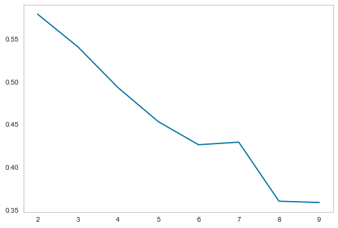

```python
plt.plot(cluster_list,sil_score)
plt.grid()
```

**Insights:**

- The silhouette scores confirm that 2 clusters is the right amount of clusters

```python
HCmodel = AgglomerativeClustering(n_clusters=2,affinity='euclidean', linkage='average')
HCmodel.fit(subset_scaled_df)
```

```
AgglomerativeClustering(linkage='average')
```

## Create cluster profile, bar plots and boxplots to understand segments better

**Going to use scaled data to review bar plots and boxplots since all the variables will be on same scale and it is easier to understand**

```python
CC_df['HC_segments'] = HCmodel.labels_ #map segments to original data set

subset_scaled_df['HC_segments'] = HCmodel.labels_ #map segments to scaled data
```

```python
cluster_profile_HC = CC_df.loc[:,CC_df.columns != 'K_means_segments'].groupby('HC_segments').mean() #create a cluster profile
```

```python
cluster_profile_HC['count_in_each_segment'] = CC_df.groupby('HC_segments')['Total_Credit_Cards'].count().values # add counts data
```

```python
cluster_profile_HC
```

| HC_segments | Avg_Credit_Limit | Total_Credit_Cards | Total_visits_bank | Total_visits_online | Total_calls_made | count_in_each_segment |
| --- | --- | --- | --- | --- | --- | --- |
| 0 | 25847.540984 | 4.37541 | 2.55082 | 1.92623 | 3.788525 | 610 |
| 1 | 141040.000000 | 8.74000 | 0.60000 | 10.90000 | 1.080000 | 50 |

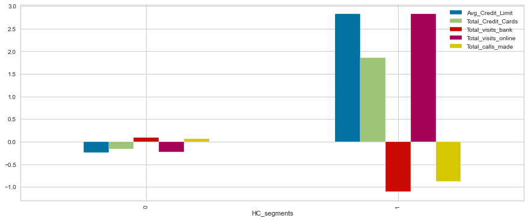

```python
subset_scaled_df.loc[:,subset_scaled_df.columns != 'K_means_segments'].groupby('HC_segments').mean().plot.bar(figsize=(15,6));
```

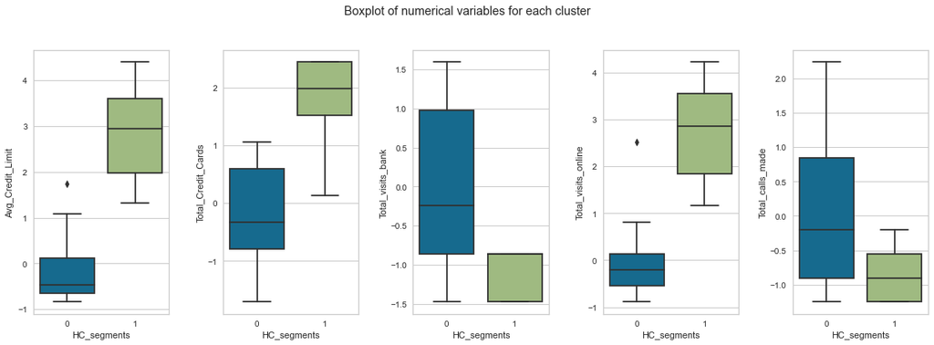

```python
fig, axes = plt.subplots(1, 5,  figsize=(16, 6))
fig.suptitle('Boxplot of numerical variables for each cluster')
counter = 0
for ii in range(5):
    sns.boxplot(ax=axes[ii],y=subset_scaled_df.iloc[:,ii],x=subset_scaled_df['HC_segments'])
    counter = counter+1

fig.tight_layout(pad=2.0)
```

**Insights:**

- Clusters 0 :
  - Avg_Credit_Limit is slightly lower than average
  - Total_Credit_Cards is slightly lower than average
  - Total_visits_bank is slightly higher than average
  - Total_visits_onlinine is slightly lower than average
  - Total_calls_made is slightly higher than average
- Cluster 1 :
  - Avg_Credit_Limit is much higher than the average
  - Total_Credit_Cards is much higher than average
  - Total_visits_bank is lower than average
  - Total_visits_onlinine is much higher than average
  - Total_calls_made is lower than average

## Compare K-Means and Hierarchial Clustering

K-means Clustering and Hierarchial Clustering came up with 2 different answers but overall were similar. K-means Clustering suggested 3 clusters, where as, Hierarchial Clustering suggested two. Hierarchial Clustering had a higher silhoutte score 0.58 to 0.516.

Both K-means and Hierarchial clustering segmented a cluster that had high credit card limits and used online method of contacting that was substantially higher than the average. There were 50 observations in this segment using both methods.

Hierarchial Clustering took longer to run than K-means, but it was nice to have a dendrograms to review.

## Business Recommendations

Using the two segments that are suggested by average linking and euclidean measurment here are my recommendations

As a recap, the differences between the two clusters is cluster one is a high credit limit and prefers online contact and is small in number. This contrasts to Cluster zero being a large in number, lower in credit limit and prefer visits or calls to the bank